# Pájaros y salmones

Análisis Multivariante - PEC 2

Jorge Vallejo Ortega

17 de January, 2021

# Ejercicio 1. Los pájaros de Hunt

**En el trabajo de Hunt et al.(1986) se estudió la capacidad reproductiva de cinco especies de aves marinas en dos colonias en el sureste del mar de Bering. Además, el apéndice de este estudio resume las colonias y los tamaños de las poblaciones de otros trabajos. El archivo `seabirds.csv` recoge los datos (número de pájaros) de 23 especies en 9 colonias en el área del norte polar y subpolar.**

**El principal interés de este ejercicio es representar las colonias de diversas formas y estudiar posibles conglomerados.**

En primer lugar, como preparación al ejercicio cargaremos los datos a memoria y examinaremos las características y estructura de los mismos.

```r
seabirds <- read.csv("./data/seabirds.csv",
                     stringsAsFactors = FALSE)

kable(
  head(seabirds),
  caption = "Ejemplo de las primeras seis observaciones en la base de datos `seabirds.csv`."
)
```

Ejemplo de las primeras seis observaciones en la base de datos `seabirds.csv`.

| Specie | CH | PLI | CI | NS | CL | CT | SI | SPI | SGI |
| --- | --- | --- | --- | --- | --- | --- | --- | --- | --- |
| Northern.fulmar | 0 | 124000 | 0 | 0 | 0 | 0 | 224 | 700 | 70000 |
| Glaucous-winged.gull | 150 | 400 | 150 | 274 | 50 | 300 | 0 | 0 | 0 |
| Black-legged.kittiwake | 40000 | 58000 | 60000 | 7550 | 25000 | 26500 | 5000 | 31000 | 72000 |
| Red-legged.kittiwake | 0 | 0 | 0 | 0 | 0 | 0 | 0 | 2200 | 220000 |
| Thick-billed.murre | 280000 | 172000 | 320000 | 400 | 30000 | 233578 | 0 | 110000 | 1500000 |
| Common.murre | 0 | 0 | 0 | 41800 | 70000 | 155719 | 5320 | 39000 | 190000 |

Si examinamos la estructura de la base de datos:

```r
str(seabirds)
```

```
## 'data.frame':    23 obs. of  10 variables:
##  $ Specie: chr  "Northern.fulmar" "Glaucous-winged.gull" "Black-legged.kittiwake" "Red-legged.kittiwake" ...
##  $ CH    : int  0 150 40000 0 280000 0 200 0 0 0 ...
##  $ PLI   : int  124000 400 58000 0 172000 0 8000 0 0 0 ...
##  $ CI    : int  0 150 60000 0 320000 0 200 0 0 0 ...
##  $ NS    : int  0 274 7550 0 400 41800 0 0 3186 41 ...
##  $ CL    : int  0 50 25000 0 30000 70000 170 0 1450 20 ...
##  $ CT    : int  0 300 26500 0 233578 155719 4 14 1494 0 ...
##  $ SI    : int  224 0 5000 0 0 5320 0 0 0 0 ...
##  $ SPI   : int  700 0 31000 2200 110000 39000 0 0 4400 1000 ...
##  $ SGI   : int  70000 0 72000 220000 1500000 190000 0 0 28000 6000 ...
```

La base de datos consta de 23 observaciones (files) y 10 variables (columnas). De las diez variables, una corresponde a la especie observada (codificada como cadena de caracteres) y las otras nueve son situaciones geográficas en las que se han obsevado colonias de dichas especies. Los valores que adoptan estas nueve variables son la cantidad de individuos de cada especie, y están codificadas como variables numéricas[^1]:

**Specie**: Nombre común de una especie de ave marina.  
**CH**: Número de individuos en la población de Cape Hay.  
**PLI**: Número de individuos en la población de Prince Leopold Island.  
**CI**: Individuos en Caburg Island.  
**NS**: Individuos en North Shields.  
**CL**: Individuos en Cape Lisburne.  
**CT**: Individuos en Cape Thompson.  
**SI**: Individuos en Skomer Island.  
**SPI**: Individuos en St. Paul Island.  
**SGI**: Individuos en George Island.

Finalmente, una forma rápida de buscar valores anómalos y valores ausentes es mediante el resumen numérico:

```r
summary(seabirds)
```

```
##     Specie                CH              PLI               CI
##  Length:23          Min.   :     0   Min.   :     0   Min.   :     0
##  Class :character   1st Qu.:     0   1st Qu.:     0   1st Qu.:     0
##  Mode  :character   Median :     0   Median :     0   Median :     0
##                     Mean   : 13928   Mean   : 15757   Mean   : 16537
##                     3rd Qu.:     0   3rd Qu.:     0   3rd Qu.:     0
##                     Max.   :280000   Max.   :172000   Max.   :320000
##        NS                CL              CT               SI
##  Min.   :    0.0   Min.   :    0   Min.   :     0   Min.   :     0
##  1st Qu.:    0.0   1st Qu.:    0   1st Qu.:     0   1st Qu.:     0
##  Median :    0.0   Median :    0   Median :     0   Median :    28
##  Mean   : 2340.6   Mean   : 5512   Mean   : 18159   Mean   : 14423
##  3rd Qu.:  169.5   3rd Qu.:   64   3rd Qu.:    30   3rd Qu.:  5160
##  Max.   :41800.0   Max.   :70000   Max.   :233578   Max.   :260000
##       SPI              SGI
##  Min.   :     0   Min.   :      0
##  1st Qu.:     0   1st Qu.:      0
##  Median :     0   Median :      0
##  Mean   : 11035   Mean   : 109522
##  3rd Qu.:  5200   3rd Qu.:  71000
##  Max.   :110000   Max.   :1500000
```

No parece haber valores anómalos (entendidos como imposiblemente elevados, negativos, o faltantes) en ninguna de las variables. Sí que podemos ver sin embargo una característica interesante de nuestros datos; la mayoría de valores son ceros. Fijémonos que en el sumario la mayoría de variables presentan valor cero en el segundo, e incluso en el tercer quintil. Esto ya nos adelanta que, en la mayoría de los lugares observados, sólo están presentes menos de la mitad de las especies.

## Ejercicio 1a. Calcular las frecuencias relativas, las frecuencias relativas marginales y la matriz de perfiles. El resultado debería ser la tabla 12.6 del libro de Krebs(2014) y que reproducimos al final de este documento.

Anteriormente sólo hemos visto una muestra con las primeras seis filas de la tabla. Aprovecharemos este ejercicio para ver la tabla en su totalidad:

```r
# Place species as row names
table_N <- seabirds
rownames(table_N) <- seabirds$Specie
table_N <- table_N[, -1]

kable(
  table_N,
  caption = "Tabla de frecuencias de cada especie de ave marina en cada una de las localizaciones."
)
```

Tabla de frecuencias de cada especie de ave marina en cada una de las localizaciones.

|  | CH | PLI | CI | NS | CL | CT | SI | SPI | SGI |
| --- | --- | --- | --- | --- | --- | --- | --- | --- | --- |
| Northern.fulmar | 0 | 124000 | 0 | 0 | 0 | 0 | 224 | 700 | 70000 |
| Glaucous-winged.gull | 150 | 400 | 150 | 274 | 50 | 300 | 0 | 0 | 0 |
| Black-legged.kittiwake | 40000 | 58000 | 60000 | 7550 | 25000 | 26500 | 5000 | 31000 | 72000 |
| Red-legged.kittiwake | 0 | 0 | 0 | 0 | 0 | 0 | 0 | 2200 | 220000 |
| Thick-billed.murre | 280000 | 172000 | 320000 | 400 | 30000 | 233578 | 0 | 110000 | 1500000 |
| Common.murre | 0 | 0 | 0 | 41800 | 70000 | 155719 | 5320 | 39000 | 190000 |
| Black.guillemot | 200 | 8000 | 200 | 0 | 170 | 4 | 0 | 0 | 0 |
| Pigeon.guillemot | 0 | 0 | 0 | 0 | 0 | 14 | 0 | 0 | 0 |
| Horned.puffin | 0 | 0 | 0 | 3186 | 1450 | 1494 | 0 | 4400 | 28000 |
| Tufted.puffin | 0 | 0 | 0 | 41 | 20 | 0 | 0 | 1000 | 6000 |
| Atlantic.puffin | 0 | 0 | 0 | 0 | 0 | 0 | 16000 | 0 | 0 |
| Pelagic.cormorant | 0 | 0 | 0 | 518 | 78 | 46 | 28 | 0 | 0 |
| Red-faced.cormorant | 0 | 0 | 0 | 0 | 0 | 0 | 0 | 2500 | 5000 |
| Shag | 0 | 0 | 0 | 0 | 0 | 0 | 30 | 0 | 0 |
| Parakeet.auklet | 0 | 0 | 0 | 65 | 0 | 0 | 0 | 34000 | 150000 |
| Crested.auklet | 0 | 0 | 0 | 0 | 0 | 0 | 0 | 6000 | 28000 |
| Least.auklet | 0 | 0 | 0 | 0 | 0 | 0 | 0 | 23000 | 250000 |
| Razorbill | 0 | 0 | 0 | 0 | 0 | 0 | 4296 | 0 | 0 |
| Manx.shearwater | 0 | 0 | 0 | 0 | 0 | 0 | 260000 | 0 | 0 |
| Storm.petrel | 0 | 0 | 0 | 0 | 0 | 0 | 12920 | 0 | 0 |
| Herring.gull | 0 | 0 | 0 | 0 | 0 | 0 | 7600 | 0 | 0 |
| Great.black-backed.gull | 0 | 0 | 0 | 0 | 0 | 0 | 314 | 0 | 0 |
| Lesser.black.backed.gull | 0 | 0 | 0 | 0 | 0 | 0 | 20000 | 0 | 0 |

### Tabla de frecuencias relativas

```r
# Create table of relative frecuencies
n <- sum(table_N) # total observed birds
table_F <- table_N/n # relative frequencies

##
# For printing relative f. data without leading zeros
# there is a solution here:
# https://stackoverflow.com/questions/53740145/remove-leading-zeros-in-numbers-within-a-data-frame
# Apply it if there is enough time
# (you will have first to prettyformat the numbers)
##

# Function for dropping leading zeros befor decimal point
# Returns a data.frame of character values
drop.leading.0 <- function(dataf) {
  prettified_t <- format(round(dataf, digits = 6), # round to this decimal
                         zero.print = "0") # What to print when the result is zero
  tableF2 <- data.frame(lapply(prettified_t,
                         function(x) gsub("^0\\.", "\\.", gsub("^-0\\.", "-\\.", as.character(x)))),
                  stringsAsFactors = FALSE, row.names = row.names(prettified_t))
  tableF2
}

# Print relative freq table
kable(
  drop.leading.0(table_F),
  caption = "Tabla de frecuencias relativas de cada especie en cada localización, redondeadas al quinto decimal.",
  align = c(rep('c', 9)) # To center the zeroes (prettier table)
)
```

|  | CH | PLI | CI | NS | CL | CT | SI | SPI | SGI |
| --- | --- | --- | --- | --- | --- | --- | --- | --- | --- |
| Northern.fulmar | 0 | .026018 | 0 | 0 | 0 | 0 | .000047 | .000147 | .014688 |
| Glaucous-winged.gull | .000031 | .000084 | .000031 | .000057 | .000010 | .000063 | 0 | 0 | 0 |
| Black-legged.kittiwake | .008393 | .012170 | .012589 | .001584 | .005246 | .005560 | .001049 | .006505 | .015107 |
| Red-legged.kittiwake | 0 | 0 | 0 | 0 | 0 | 0 | 0 | .000462 | .046161 |
| Thick-billed.murre | .058751 | .036090 | .067144 | .000084 | .006295 | .049010 | 0 | .023081 | .314737 |
| Common.murre | 0 | 0 | 0 | .008771 | .014688 | .032674 | .001116 | .008183 | .039867 |
| Black.guillemot | .000042 | .001679 | .000042 | 0 | .000036 | .000001 | 0 | 0 | 0 |
| Pigeon.guillemot | 0 | 0 | 0 | 0 | 0 | .000003 | 0 | 0 | 0 |
| Horned.puffin | 0 | 0 | 0 | .000669 | .000304 | .000313 | 0 | .000923 | .005875 |
| Tufted.puffin | 0 | 0 | 0 | .000009 | .000004 | 0 | 0 | .000210 | .001259 |
| Atlantic.puffin | 0 | 0 | 0 | 0 | 0 | 0 | .003357 | 0 | 0 |
| Pelagic.cormorant | 0 | 0 | 0 | .000109 | .000016 | .000010 | .000006 | 0 | 0 |
| Red-faced.cormorant | 0 | 0 | 0 | 0 | 0 | 0 | 0 | .000525 | .001049 |
| Shag | 0 | 0 | 0 | 0 | 0 | 0 | .000006 | 0 | 0 |
| Parakeet.auklet | 0 | 0 | 0 | .000014 | 0 | 0 | 0 | .007134 | .031474 |
| Crested.auklet | 0 | 0 | 0 | 0 | 0 | 0 | 0 | .001259 | .005875 |
| Least.auklet | 0 | 0 | 0 | 0 | 0 | 0 | 0 | .004826 | .052456 |
| Razorbill | 0 | 0 | 0 | 0 | 0 | 0 | .000901 | 0 | 0 |
| Manx.shearwater | 0 | 0 | 0 | 0 | 0 | 0 | .054554 | 0 | 0 |
| Storm.petrel | 0 | 0 | 0 | 0 | 0 | 0 | .002711 | 0 | 0 |
| Herring.gull | 0 | 0 | 0 | 0 | 0 | 0 | .001595 | 0 | 0 |
| Great.black-backed.gull | 0 | 0 | 0 | 0 | 0 | 0 | .000066 | 0 | 0 |
| Lesser.black.backed.gull | 0 | 0 | 0 | 0 | 0 | 0 | .004196 | 0 | 0 |

### Tabla con frecuencias marginales

```r
# Design table
table_M <- table_F
table_M$Suma <- apply(table_M, 1, sum) # Add row margin
table_M <- rbind(table_M, # Add columns margin
                      Suma = apply(table_M, 2, sum))

# Print table
kable(
  drop.leading.0(table_M),
  caption = "Tabla de frecuencias relativas más las frecuencias marginales para filas y columnas.",
  align = c(rep('c', 9)) # To center the zeroes (prettier table)
)
```

Tabla de frecuencias relativas más las frecuencias marginales para filas y columnas.

|  | CH | PLI | CI | NS | CL | CT | SI | SPI | SGI | Suma |
| --- | --- | --- | --- | --- | --- | --- | --- | --- | --- | --- |
| Northern.fulmar | 0 | .026018 | 0 | 0 | 0 | 0 | .000047 | .000147 | .014688 | .040900 |
| Glaucous-winged.gull | .000031 | .000084 | .000031 | .000057 | .000010 | .000063 | 0 | 0 | 0 | .000278 |
| Black-legged.kittiwake | .008393 | .012170 | .012589 | .001584 | .005246 | .005560 | .001049 | .006505 | .015107 | .068203 |
| Red-legged.kittiwake | 0 | 0 | 0 | 0 | 0 | 0 | 0 | .000462 | .046161 | .046623 |
| Thick-billed.murre | .058751 | .036090 | .067144 | .000084 | .006295 | .049010 | 0 | .023081 | .314737 | .555191 |
| Common.murre | 0 | 0 | 0 | .008771 | .014688 | .032674 | .001116 | .008183 | .039867 | .105298 |
| Black.guillemot | .000042 | .001679 | .000042 | 0 | .000036 | .000001 | 0 | 0 | 0 | .001799 |
| Pigeon.guillemot | 0 | 0 | 0 | 0 | 0 | .000003 | 0 | 0 | 0 | .000003 |
| Horned.puffin | 0 | 0 | 0 | .000669 | .000304 | .000313 | 0 | .000923 | .005875 | .008085 |
| Tufted.puffin | 0 | 0 | 0 | .000009 | .000004 | 0 | 0 | .000210 | .001259 | .001482 |
| Atlantic.puffin | 0 | 0 | 0 | 0 | 0 | 0 | .003357 | 0 | 0 | .003357 |
| Pelagic.cormorant | 0 | 0 | 0 | .000109 | .000016 | .000010 | .000006 | 0 | 0 | .000141 |
| Red-faced.cormorant | 0 | 0 | 0 | 0 | 0 | 0 | 0 | .000525 | .001049 | .001574 |
| Shag | 0 | 0 | 0 | 0 | 0 | 0 | .000006 | 0 | 0 | .000006 |
| Parakeet.auklet | 0 | 0 | 0 | .000014 | 0 | 0 | 0 | .007134 | .031474 | .038621 |
| Crested.auklet | 0 | 0 | 0 | 0 | 0 | 0 | 0 | .001259 | .005875 | .007134 |
| Least.auklet | 0 | 0 | 0 | 0 | 0 | 0 | 0 | .004826 | .052456 | .057282 |
| Razorbill | 0 | 0 | 0 | 0 | 0 | 0 | .000901 | 0 | 0 | .000901 |
| Manx.shearwater | 0 | 0 | 0 | 0 | 0 | 0 | .054554 | 0 | 0 | .054554 |
| Storm.petrel | 0 | 0 | 0 | 0 | 0 | 0 | .002711 | 0 | 0 | .002711 |
| Herring.gull | 0 | 0 | 0 | 0 | 0 | 0 | .001595 | 0 | 0 | .001595 |
| Great.black-backed.gull | 0 | 0 | 0 | 0 | 0 | 0 | .000066 | 0 | 0 | .000066 |
| Lesser.black.backed.gull | 0 | 0 | 0 | 0 | 0 | 0 | .004196 | 0 | 0 | .004196 |
| Suma | .067217 | .076040 | .079807 | .011296 | .026599 | .087634 | .069605 | .053253 | .528548 | 1.000000 |

### Matrices de perfiles

```r
# Frecuencias relativas condicionadas por filas
table_Pf <- sweep(table_F, 1, table_M$Suma, "/")

kable(
  drop.leading.0(table_Pf),
  caption = "Matriz de perfiles de fila",
  align = c(rep('c', 9)) # To center the zeroes (prettier table)
)
```

Matriz de perfiles de fila

[output not shown]

```r
# Frecuencias relativas condicionadas por columnas
table_Pc <- sweep(table_F, 2, colSums(table_F), "/")

kable(
  drop.leading.0(table_Pc),
  caption = "Matriz de perfiles de columna",
  align = c(rep('c', 9)) # To center the zeroes (prettier table)
)
```

Matriz de perfiles de columna

|  | CH | PLI | CI | NS | CL | CT | SI | SPI | SGI |
| --- | --- | --- | --- | --- | --- | --- | --- | --- | --- |
| Northern.fulmar | 0 | .342163 | 0 | 0 | 0 | 0 | .000675 | .002758 | .027789 |
| Glaucous-winged.gull | .000468 | .001104 | .000394 | .005090 | .000394 | .000718 | 0 | 0 | 0 |
| Black-legged.kittiwake | .124863 | .160044 | .157749 | .140246 | .197211 | .063449 | .015072 | .122143 | .028583 |
| Red-legged.kittiwake | 0 | 0 | 0 | 0 | 0 | 0 | 0 | .008668 | .087336 |
| Thick-billed.murre | .874044 | .474614 | .841330 | .007430 | .236653 | .559261 | 0 | .433412 | .595474 |
| Common.murre | 0 | 0 | 0 | .776461 | .552190 | .372841 | .016037 | .153664 | .075427 |
| Black.guillemot | .000624 | .022075 | .000526 | 0 | .001341 | .000010 | 0 | 0 | 0 |
| Pigeon.guillemot | 0 | 0 | 0 | 0 | 0 | .000034 | 0 | 0 | 0 |
| Horned.puffin | 0 | 0 | 0 | .059182 | .011438 | .003577 | 0 | .017336 | .011116 |
| Tufted.puffin | 0 | 0 | 0 | .000762 | .000158 | 0 | 0 | .003940 | .002382 |
| Atlantic.puffin | 0 | 0 | 0 | 0 | 0 | 0 | .048232 | 0 | 0 |
| Pelagic.cormorant | 0 | 0 | 0 | .009622 | .000615 | .000110 | .000084 | 0 | 0 |
| Red-faced.cormorant | 0 | 0 | 0 | 0 | 0 | 0 | 0 | .009850 | .001985 |
| Shag | 0 | 0 | 0 | 0 | 0 | 0 | .000090 | 0 | 0 |
| Parakeet.auklet | 0 | 0 | 0 | .001207 | 0 | 0 | 0 | .133964 | .059547 |
| Crested.auklet | 0 | 0 | 0 | 0 | 0 | 0 | 0 | .023641 | .011116 |
| Least.auklet | 0 | 0 | 0 | 0 | 0 | 0 | 0 | .090623 | .099246 |
| Razorbill | 0 | 0 | 0 | 0 | 0 | 0 | .012950 | 0 | 0 |
| Manx.shearwater | 0 | 0 | 0 | 0 | 0 | 0 | .783765 | 0 | 0 |
| Storm.petrel | 0 | 0 | 0 | 0 | 0 | 0 | .038947 | 0 | 0 |
| Herring.gull | 0 | 0 | 0 | 0 | 0 | 0 | .022910 | 0 | 0 |
| Great.black-backed.gull | 0 | 0 | 0 | 0 | 0 | 0 | .000947 | 0 | 0 |
| Lesser.black.backed.gull | 0 | 0 | 0 | 0 | 0 | 0 | .060290 | 0 | 0 |

## Ejercicio 1b. Calcular la matriz de distancias ji-cuadrado entre los perfiles de las columnas y su inercia total.

### Matriz de distancias ji-cuadrado entre columnas

```r
ncols <- ncol(table_Pc)
# Initialize matrix to store results
D2_chisq <- matrix(0, ncols, ncols)
# Calculate distances
for (i in 1:(ncols)){
  for (j in 1:ncols){
    D2_chisq[i,j] <- t(table_Pc[,i ] - table_Pc[,j ]) %*%
       diag(1 / rowSums(table_F)) %*% # Diagonal matrix from file margin
      (table_Pc[, i] - table_Pc[, j])
  }
}
# Names for distance matrix
rownames(D2_chisq) <- colnames(D2_chisq) <- colnames(table_Pc)

# Print table
kable(
D2_chisq,
digits = 5,
caption = "Matriz de distancias ji-cuadrado entre columnas",
  align = c(rep('c', 9)))
```

Matriz de distancias ji-cuadrado entre columnas

|  | CH | PLI | CI | NS | CL | CT | SI | SPI | SGI |
| --- | --- | --- | --- | --- | --- | --- | --- | --- | --- |
| CH | 0.00000 | 3.42524 | 0.01781 | 8.25111 | 3.72342 | 1.55643 | 15.46510 | 1.37256 | 0.81591 |
| PLI | 3.42524 | 0.00000 | 3.36474 | 10.40726 | 6.14013 | 4.60560 | 17.75168 | 4.13747 | 3.49171 |
| CI | 0.01781 | 3.36474 | 0.00000 | 8.15435 | 3.59639 | 1.59643 | 15.48546 | 1.34075 | 0.89342 |
| NS | 8.25111 | 10.40726 | 8.15435 | 0.00000 | 1.55953 | 3.27773 | 20.80417 | 5.73199 | 6.97465 |
| CL | 3.72342 | 6.14013 | 3.59639 | 1.55953 | 0.00000 | 0.76649 | 17.24585 | 2.42871 | 3.28116 |
| CT | 1.55643 | 4.60560 | 1.59643 | 3.27773 | 0.76649 | 0.00000 | 15.71938 | 1.32131 | 1.33949 |
| SI | 15.46510 | 17.75168 | 15.48546 | 20.80417 | 17.24585 | 15.71938 | 0.00000 | 15.39261 | 15.06801 |
| SPI | 1.37256 | 4.13747 | 1.34075 | 5.73199 | 2.42871 | 1.32131 | 15.39261 | 0.00000 | 0.59425 |
| SGI | 0.81591 | 3.49171 | 0.89342 | 6.97465 | 3.28116 | 1.33949 | 15.06801 | 0.59425 | 0.00000 |

### Inercia total de la tabla

```r
# X^2 es el valor del test estadistico chi-cuadrado
# n es la suma de todos los valores de la tabla de contingencia

# Si la inercia total es igual a X^2/n:
chisq.test(table_N)$statistic[[1]]/n
```

```
## [1] 1.565692
```

## 1c. Con la matriz de distancias ji-cuadrado entre los perfiles realizar un escalado multidimensional. Dibujar las coordenadas principales para las columnas.

### Escalado multidimensional

Usaremos la función `cmdscale()` para realizar el escalado sobre la matriz de distancias entre los perfiles.

```r
MDS_seabirds_columns <- cmdscale(sqrt(D2_chisq),
                                 k=8,
                                 eig = TRUE)
MDS_seabirds_columns$points
```

```
##           [,1]       [,2]        [,3]        [,4]         [,5]
## CH   0.2543284 -0.8114068 -0.42602119  0.34227048 -0.099355583
## PLI  0.2664595 -1.0974964  1.35821508 -0.02584123  0.008702316
## CI   0.2626170 -0.7948645 -0.39857520  0.35487965 -0.029971434
## NS   0.8736018  1.8658695  0.28848623 -0.04866027 -0.280702981
## CL   0.6653185  0.9227070  0.05846293  0.18962668  0.379840972
## CT   0.5007326  0.2909326 -0.20577388  0.20979045  0.020048190
## SI  -3.4331177  0.4229940  0.03484996  0.01112320  0.001929472
## SPI  0.3489774 -0.2426699 -0.36234995 -0.61582111  0.228022138
## SGI  0.2610823 -0.5560655 -0.34729397 -0.41736784 -0.228513090
##             [,6]          [,7]          [,8]
## CH   0.107903136 -0.0236575986  6.661949e-03
## PLI -0.003515234 -0.0135203809 -8.533571e-06
## CI   0.187409247  0.0488422627 -6.113595e-03
## NS   0.165239014 -0.0081833251 -8.177873e-05
## CL  -0.084361458  0.1270373842  1.289681e-03
## CT  -0.315526285 -0.1681524520 -1.737264e-03
## SI   0.002136755 -0.0003666701  4.523941e-08
## SPI  0.191813205 -0.0860054881 -3.631759e-06
## SGI -0.251098380  0.1240062679 -6.872788e-06
```

Si examinamos los valores propios:

```r
MDS_seabirds_columns$eig
```

```
## [1]  1.363746e+01  7.459209e+00  2.567215e+00  8.796498e-01  3.385369e-01
## [6]  2.806026e-01  7.038339e-02  8.644579e-05 -2.093157e-16
```

Vemos que uno de los valores propios es negativo. Esto era de esperar, ya que las distancias son no Euclídeas.

Para decidir cuántos vectores propios serían necesarios para recuperar suficiente información, usaremos los criterios sugeridos por Mardia buscando el primer valor por encima de 0.8:

$P_m^{(1)}$:

```r
cumsum(abs(MDS_seabirds_columns$eig)) / sum(abs(MDS_seabirds_columns$eig))
```

```
## [1] 0.5404582 0.8360698 0.9378096 0.9726705 0.9860869 0.9972073 0.9999966
## [8] 1.0000000 1.0000000
```

$P_m^{(2)}$:

```r
cumsum(abs(MDS_seabirds_columns$eig^2)) / sum(abs(MDS_seabirds_columns$eig^2))
```

```
## [1] 0.7463610 0.9696501 0.9960989 0.9992042 0.9996641 0.9999801 1.0000000
## [8] 1.0000000 1.0000000
```

Ambos criterios sugieren que dos vectores propios recogen la mayor parte de la información contenida en la matriz de distancias original. Esto nos permitirá una representación bastante fiel en un gráfico bidimensional.

### Representación gráfica de las coordenadas principales

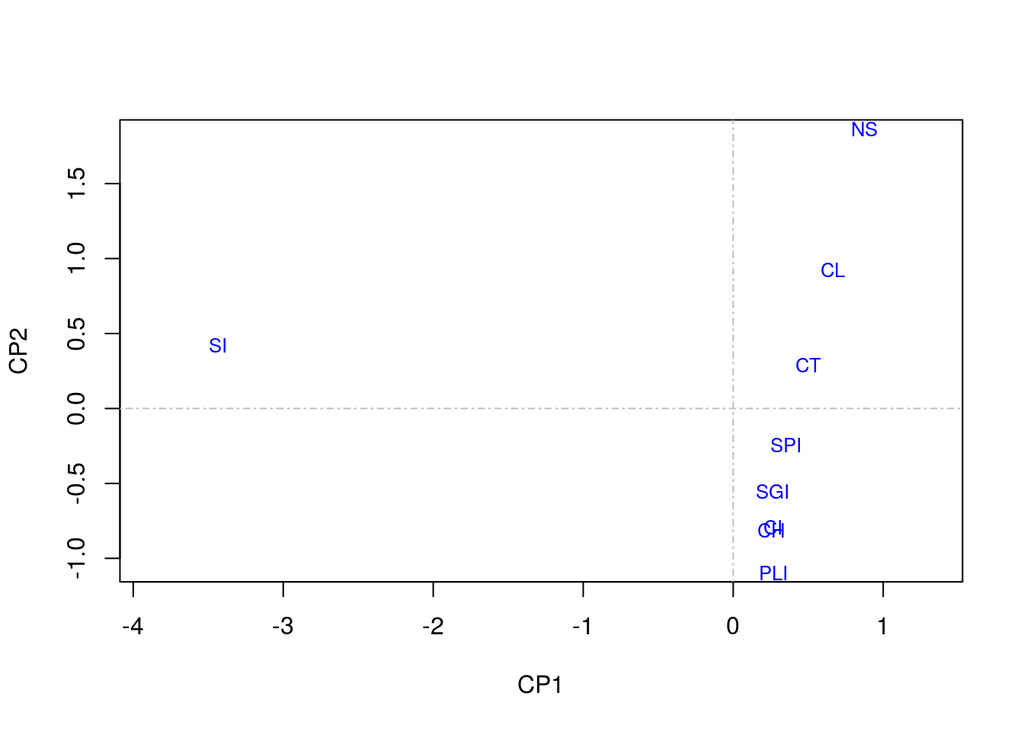

Representación gráfica de las distancias ji-cuadrado entre las columas (lugares geográficos) de la base de datos seabirds.

```r
# draw the graph
eqscplot(MDS_seabirds_columns$points[, 1:2],ty="n",xlab="CP1",ylab="CP2")
abline(v=0,h=0, col="gray",lty=4)
# draw the columns
text(MDS_seabirds_columns$points[,1],MDS_seabirds_columns$points[,2],labels=colnames(table_N),cex=0.8,
     col = "blue")
```

Vemos que la primera coordenada principal está dominada por la distancia entre SI (Skomer Island) y el resto de columnas, que se distancian poco entre sí. Sin embargo, la segunda coordenada principal describe una separación gradual y poco brusca entre todas las columnas, siendo CH y CI (Cape Hay y Caburg Island) las columnas más parecidas entre sí y NS-PLI (North Shields y Prince Leopold Island) las columnas más alejadas en la segunda coordenada.

## 1d. Realizar un análisis de correspondencias y calcular las inercias principales (en %) y la inercia total con los valores propios.

Para este ejercicio utilizaremos el paquete 'ca' de R, específico para realizar análisis de correspondencias mediante descomposición de valores singulares.

```r
CA_seabirds <- ca(table_F)
```

### Inercias principales (en %)

```r
inertias <- summary(CA_seabirds)$scree
inertias_p_seabirds <-data.frame(
  'valores propios' = as.character(inertias[,1]),
  'inercia' = as.character(sprintf("%.5g", inertias[,2])),
  'porcentaje' = as.character(sprintf("%.2f%%", inertias[,3]))
)
  # summary(CA_seabirds)$scree)

kable(
  t(inertias_p_seabirds),
  align = (c(rep('c', 8))),
  caption = "Tabla de inercias principales."
)
```

Tabla de inercias principales.

| valores.propios | 1 | 2 | 3 | 4 | 5 | 6 | 7 | 8 |
| --- | --- | --- | --- | --- | --- | --- | --- | --- |
| inercia | 0.96625 | 0.25664 | 0.20592 | 0.098617 | 0.026177 | 0.0083129 | 0.003765 | 6.0944e-06 |
| porcentaje | 61.71% | 16.39% | 13.15% | 6.30% | 1.67% | 0.53% | 0.24% | 0.00% |

### Inercia total

```r
sum(inertias[,2])
```

```
## [1] 1.565692
```

### Dibujar una representación simétrica del CA. A pesar de la confusión de nombres, ¿cuales son las especies que caracterizan a la colonia SI (Skomer Island, Irish Sea)?

En la representación simétrica, tanto las filas como las columnas de la tabla de datos se representarán según sus coordenadas principales.

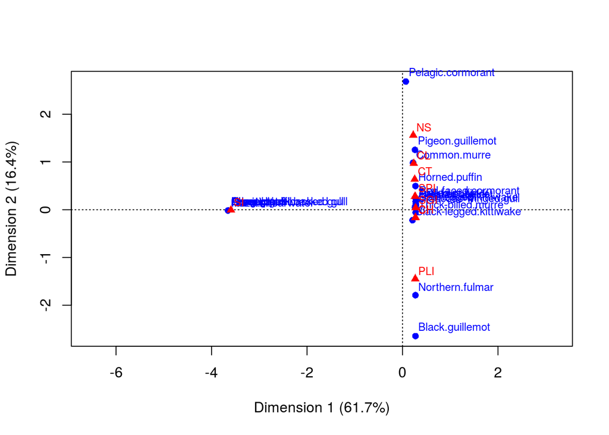

Representación en coordenadas principales (simétrica) de colonias y especies.

```r
CA_seabirds_plot <- plot(CA_seabirds)
```

Para las especies que caracterizan a la colonia en Skomer Island, filtraremos las coordenadas de las especies para aislar sólo las que estén cerca de SI en la gráfica:

```r
# Coordinates of colony SI
CA_seabirds_plot$cols["SI",]
```

```
##         Dim1         Dim2
## -3.593663169 -0.008182216
```

```r
# Little range around SI x coordinate
range1 <- c(CA_seabirds_plot$cols["SI",1]*1.1,
            CA_seabirds_plot$cols["SI",1]*0.9)
# Filter species that are inside the range above
kable(
CA_seabirds_plot$rows[CA_seabirds_plot$rows[,"Dim1"] >= range1[1] &
                        CA_seabirds_plot$rows[,"Dim1"] <= range1[2],],
caption = "Tabla con las especies de aves que caracterizan a la colonia en Smoker Island (SI), y los valores de sus coordenadas en la gráfica.",
align = 'c'
)
```

Tabla con las especies de aves que caracterizan a la colonia en Smoker Island (SI), y los valores de sus coordenadas en la gráfica.

|  | Dim1 | Dim2 |
| --- | --- | --- |
| Atlantic.puffin | -3.655886 | -0.0161514 |
| Shag | -3.655886 | -0.0161514 |
| Razorbill | -3.655886 | -0.0161514 |
| Manx.shearwater | -3.655886 | -0.0161514 |
| Storm.petrel | -3.655886 | -0.0161514 |
| Herring.gull | -3.655886 | -0.0161514 |
| Great.black-backed.gull | -3.655886 | -0.0161514 |
| Lesser.black.backed.gull | -3.655886 | -0.0161514 |

Tengamos en cuenta sin embargo, que la gráfica simétrica es la proyección simultánea de gráficas diferentes (la de columnas y la de filas) y por tanto la cercanía de filas a columnas no puede ser interpretada directamente (Greenacre 2017). En este caso, la interpretación parece correcta si atendemos a que las especies de la tabla anterior siguen un patrón de distanciamiento respecto al resto de especies igual al que sigue la colonia SI respecto al resto de colonias (muy distanciadas en la primera coordenada principal pero no en la segunda).

## 1d. Calcular matrices de similaridad entre columnas usando diferentes definiciones de la distancia de Canberra

### Primera definición

$$d_C(\mathbf{p,q}) = \sum_{i=1}^k \frac{|p_i - q_i|}{|p_i| + |q_i|}$$

```r
ncols <- ncol(table_N)
# Initialize matrix to store results
Can1 <- matrix(0, ncols, ncols)
# Names for distance matrix
rownames(Can1) <- colnames(Can1) <- colnames(table_N)
# Calculate distances
for (i in 1:(ncols)){
  for (j in 1:ncols){
    # Check denominators that equal zero
    denominators <- abs(table_N[,i ]) + abs(table_N[,j ])
    numerators <- abs(table_N[,i ] - table_N[,j ])
    zero_d <- which(denominators == 0)
    Can1[i, j] <- sum(numerators[-zero_d]/
                        denominators[-zero_d])
  }
}


# Print table
kable(
Can1,
digits = 2,
caption = "Matriz de distancias de Canberra usando la primera definición.",
  align = c(rep('c', 9)))
```

Matriz de distancias de Canberra usando la primera definición.

|  | CH | PLI | CI | NS | CL | CT | SI | SPI | SGI |
| --- | --- | --- | --- | --- | --- | --- | --- | --- | --- |
| CH | 0.00 | 2.83 | 0.27 | 7.97 | 5.62 | 5.59 | 14.78 | 11.56 | 11.97 |
| PLI | 2.83 | 0.00 | 2.72 | 8.95 | 7.84 | 6.67 | 14.84 | 11.51 | 11.18 |
| CI | 0.27 | 2.72 | 0.00 | 8.07 | 5.82 | 5.84 | 14.85 | 11.81 | 11.74 |
| NS | 7.97 | 8.95 | 8.07 | 0.00 | 5.91 | 7.37 | 15.87 | 10.71 | 12.23 |
| CL | 5.62 | 7.84 | 5.82 | 5.91 | 0.00 | 5.12 | 16.00 | 11.43 | 12.80 |
| CT | 5.59 | 6.67 | 5.84 | 7.37 | 5.12 | 0.00 | 15.86 | 12.53 | 13.19 |
| SI | 14.78 | 14.84 | 14.85 | 15.87 | 16.00 | 15.86 | 0.00 | 19.00 | 19.81 |
| SPI | 11.56 | 11.51 | 11.81 | 10.71 | 11.43 | 12.53 | 19.00 | 0.00 | 7.77 |
| SGI | 11.97 | 11.18 | 11.74 | 12.23 | 12.80 | 13.19 | 19.81 | 7.77 | 0.00 |

No, evidentemente esta definición no nos llevará a la tabla 12.7 de Krebs. A simple vista ya vemos que si restamos las distancias a 1 (para hallar la similaridad) obtendremos valores negativos.

### Segunda definición

$$d_C(\mathbf{p,q}) = \frac{1}{k} \sum_{i=1}^k \frac{|p_i - q_i|}{|p_i| + |q_i|}$$

```r
ncols <- ncol(table_N)
nrows <- nrow(table_N)
# Initialize matrix to store results
Can2 <- matrix(0, ncols, ncols)
# Names for distance matrix
rownames(Can2) <- colnames(Can2) <- colnames(table_N)
# Calculate distances
for (i in 1:(ncols)){
  for (j in 1:ncols){
    # Check denominators that equal zero
    denominators <- abs(table_N[,i ]) + abs(table_N[,j ])
    numerators <- abs(table_N[,i ] - table_N[,j ])
    zero_d <- which(denominators == 0)
    Can2[i, j] <- sum(numerators[-zero_d]/
                        denominators[-zero_d])/nrows
  }
}


# Print table
kable(
Can2,
digits = 2,
caption = "Matriz de distancias de Canberra usando la segunda definición.",
  align = c(rep('c', 9)))
```

Matriz de distancias de Canberra usando la segunda definición.

|  | CH | PLI | CI | NS | CL | CT | SI | SPI | SGI |
| --- | --- | --- | --- | --- | --- | --- | --- | --- | --- |
| CH | 0.00 | 0.12 | 0.01 | 0.35 | 0.24 | 0.24 | 0.64 | 0.50 | 0.52 |
| PLI | 0.12 | 0.00 | 0.12 | 0.39 | 0.34 | 0.29 | 0.65 | 0.50 | 0.49 |
| CI | 0.01 | 0.12 | 0.00 | 0.35 | 0.25 | 0.25 | 0.65 | 0.51 | 0.51 |
| NS | 0.35 | 0.39 | 0.35 | 0.00 | 0.26 | 0.32 | 0.69 | 0.47 | 0.53 |
| CL | 0.24 | 0.34 | 0.25 | 0.26 | 0.00 | 0.22 | 0.70 | 0.50 | 0.56 |
| CT | 0.24 | 0.29 | 0.25 | 0.32 | 0.22 | 0.00 | 0.69 | 0.54 | 0.57 |
| SI | 0.64 | 0.65 | 0.65 | 0.69 | 0.70 | 0.69 | 0.00 | 0.83 | 0.86 |
| SPI | 0.50 | 0.50 | 0.51 | 0.47 | 0.50 | 0.54 | 0.83 | 0.00 | 0.34 |
| SGI | 0.52 | 0.49 | 0.51 | 0.53 | 0.56 | 0.57 | 0.86 | 0.34 | 0.00 |

La tabla 12.7 en realidad es una tabla de similaridades, así que para transformar nuestra tabla de distancias en una de similaridas restaremos cada valor de la tabla a la unidad (1-C):

```r
kable(
matrix(1, nrow = 9, ncol = 9) - # matrix of ones
  Can2, # distance matrix to be converted into similarities
digits = 2,
caption = "Matriz de similaridades a partir de distancias de Canberra usando la segunda definición.",
  align = c(rep('c', 9))
)
```

Matriz de similaridades a partir de distancias de Canberra usando la segunda definición.

|  | CH | PLI | CI | NS | CL | CT | SI | SPI | SGI |
| --- | --- | --- | --- | --- | --- | --- | --- | --- | --- |
| CH | 1.00 | 0.88 | 0.99 | 0.65 | 0.76 | 0.76 | 0.36 | 0.50 | 0.48 |
| PLI | 0.88 | 1.00 | 0.88 | 0.61 | 0.66 | 0.71 | 0.35 | 0.50 | 0.51 |
| CI | 0.99 | 0.88 | 1.00 | 0.65 | 0.75 | 0.75 | 0.35 | 0.49 | 0.49 |
| NS | 0.65 | 0.61 | 0.65 | 1.00 | 0.74 | 0.68 | 0.31 | 0.53 | 0.47 |
| CL | 0.76 | 0.66 | 0.75 | 0.74 | 1.00 | 0.78 | 0.30 | 0.50 | 0.44 |
| CT | 0.76 | 0.71 | 0.75 | 0.68 | 0.78 | 1.00 | 0.31 | 0.46 | 0.43 |
| SI | 0.36 | 0.35 | 0.35 | 0.31 | 0.30 | 0.31 | 1.00 | 0.17 | 0.14 |
| SPI | 0.50 | 0.50 | 0.49 | 0.53 | 0.50 | 0.46 | 0.17 | 1.00 | 0.66 |
| SGI | 0.48 | 0.51 | 0.49 | 0.47 | 0.44 | 0.43 | 0.14 | 0.66 | 1.00 |

Si la comparamos con la tabla 12.7 veremos que es casi igual. Hay pequeñas diferencias en los valores probablemente debidas a que para los cálculos de la tabla 12.7 los ceros de la matriz de frecuencias se han sustituido por el valor 0.1 (Krebs 2014); mientras que en el algoritmo que hemos usado aquí hemos eliminado del sumatorio las divisiones con denominador igual a cero para evitar valores NaN.

### Tercera definición

$$d_C(\mathbf{p,q}) = \frac{k}{k - n_z} \sum_{i=1}^k \frac{|p_i - q_i|}{|p_i| + |q_i|}$$

```r
ncols <- ncol(table_N)
nrows <- nrow(table_N)
# Initialize matrix to store results
Can3 <- matrix(0, ncols, ncols)
# Names for distance matrix
rownames(Can3) <- colnames(Can3) <- colnames(table_N)
# Calculate distances
for (i in 1:(ncols)){
  for (j in 1:ncols){
    # Check denominators that equal zero
    denominators <- abs(table_N[,i ]) + abs(table_N[,j ])
    numerators <- abs(table_N[,i ] - table_N[,j ])
    zero_d <- which(denominators == 0)
    Can3[i, j] <- sum(numerators[-zero_d]/
                        denominators[-zero_d])*
      (nrows/(nrows-length(zero_d))) # The more zeroes, the bigger the distance
  }
}


# Print table
kable(
Can3,
digits = 2,
caption = "Matriz de distancias de Canberra usando la tercera definición.",
  align = c(rep('c', 9)))
```

Matriz de distancias de Canberra usando la tercera definición.

|  | CH | PLI | CI | NS | CL | CT | SI | SPI | SGI |
| --- | --- | --- | --- | --- | --- | --- | --- | --- | --- |
| CH | 0.00 | 13.01 | 1.53 | 20.37 | 16.15 | 16.06 | 22.66 | 20.46 | 21.18 |
| PLI | 13.01 | 0.00 | 12.53 | 20.59 | 20.03 | 17.04 | 22.75 | 20.37 | 19.78 |
| CI | 1.53 | 12.53 | 0.00 | 20.61 | 16.74 | 16.78 | 22.76 | 20.89 | 20.77 |
| NS | 20.37 | 20.59 | 20.61 | 0.00 | 15.10 | 16.96 | 21.48 | 18.95 | 21.64 |
| CL | 16.15 | 20.03 | 16.74 | 15.10 | 0.00 | 13.09 | 21.64 | 18.77 | 21.03 |
| CT | 16.06 | 17.04 | 16.78 | 16.96 | 13.09 | 0.00 | 21.46 | 19.21 | 20.23 |
| SI | 22.66 | 22.75 | 22.76 | 21.48 | 21.64 | 21.46 | 0.00 | 21.85 | 22.78 |
| SPI | 20.46 | 20.37 | 20.89 | 18.95 | 18.77 | 19.21 | 21.85 | 0.00 | 16.24 |
| SGI | 21.18 | 19.78 | 20.77 | 21.64 | 21.03 | 20.23 | 22.78 | 16.24 | 0.00 |

Si comparamos esta matriz con la obtenida con la función `dist()` de R:

```r
CanR <- dist(t(table_N), # transposed because the function works with rows
     method = "canberra",
     diag = TRUE)

kable(
  as.matrix(CanR),
  digits = 2,
  caption = "Matriz de distancias según el método Canberra obtenida mediante la función dist() del paquete `stats`."
)
```

Matriz de distancias según el método Canberra obtenida mediante la función dist() del paquete `stats`.

|  | CH | PLI | CI | NS | CL | CT | SI | SPI | SGI |
| --- | --- | --- | --- | --- | --- | --- | --- | --- | --- |
| CH | 0.00 | 13.01 | 1.53 | 20.37 | 16.15 | 16.06 | 22.66 | 20.46 | 21.18 |
| PLI | 13.01 | 0.00 | 12.53 | 20.59 | 20.03 | 17.04 | 22.75 | 20.37 | 19.78 |
| CI | 1.53 | 12.53 | 0.00 | 20.61 | 16.74 | 16.78 | 22.76 | 20.89 | 20.77 |
| NS | 20.37 | 20.59 | 20.61 | 0.00 | 15.10 | 16.96 | 21.48 | 18.95 | 21.64 |
| CL | 16.15 | 20.03 | 16.74 | 15.10 | 0.00 | 13.09 | 21.64 | 18.77 | 21.03 |
| CT | 16.06 | 17.04 | 16.78 | 16.96 | 13.09 | 0.00 | 21.46 | 19.21 | 20.23 |
| SI | 22.66 | 22.75 | 22.76 | 21.48 | 21.64 | 21.46 | 0.00 | 21.85 | 22.78 |
| SPI | 20.46 | 20.37 | 20.89 | 18.95 | 18.77 | 19.21 | 21.85 | 0.00 | 16.24 |
| SGI | 21.18 | 19.78 | 20.77 | 21.64 | 21.03 | 20.23 | 22.78 | 16.24 | 0.00 |

Deducimos que esta tercera definición de distancia de Canberra es la que usa R, ya que ambas matrices son iguales[^2].

## 1f. Realizar un MDS con la distancia de Canberra de **R**.

Usaremos la función `cmdscale()` para realizar el escalado sobre la matriz de distancias entre columnas.

```r
# We are using here the distance matrix from function dist()
MDS_CanR_columns <- cmdscale(CanR,
                                 k=8,
                                 eig = TRUE)
MDS_CanR_columns$points
```

```
##           [,1]       [,2]      [,3]       [,4]       [,5]         [,6]
## CH  -9.6943059  0.4824349  1.443135  0.8647548 -3.1552222 -1.683697299
## PLI -7.1363423  4.1973750  2.184339 -5.2870034  3.9019001  3.795009883
## CI  -9.9150956  1.2453807  1.802209  0.3652163 -2.5906658 -2.499692315
## NS   5.1224365 -7.6217340 -4.591713 -7.7748532  0.9857337 -2.922148265
## CL   0.3983870 -7.2556942 -4.652237  4.7761965 -1.5461186 -2.058804860
## CT  -0.9660238 -4.7112235 -3.071482  4.5520053  5.2502917  5.313903166
## SI   8.5558651 -3.0161873 13.825388  0.9427209 -0.2967583 -0.001981805
## SPI  7.5025168  5.7499895 -4.289123 -0.7615193 -7.0211678  4.790288790
## SGI  6.1325622 10.9296589 -2.650516  2.3224822  4.4720071 -4.732877294
##            [,7]          [,8]
## CH   1.86664989  0.2297300439
## PLI -3.67137244  0.0116254248
## CI   1.48534530 -0.2305301012
## NS   1.64170699  0.0034825560
## CL  -4.76136073  0.0003892787
## CT   2.98080963 -0.0161108975
## SI  -0.07116671  0.0004732796
## SPI  0.25715470 -0.0139171695
## SGI  0.27223337  0.0148575852
```

### Comprobar que se trata de una distancia euclídea.

Si examinamos los valores propios:

```r
MDS_CanR_columns$eig
```

```
## [1]  4.376462e+02  3.139504e+02  2.788262e+02  1.396773e+02  1.322032e+02
## [6]  1.098476e+02  5.356590e+01  1.067417e-01 -1.659181e-15
```

Vemos que el último valor propio es negativo pero también básicamente cero, así que no estoy seguro de si se puede interpretar como distancia no-euclídea.

Podemos contrastarlo usando la función `is.euclid()` del paquete `ade4`:

```r
is.euclid(CanR)
```

```
## [1] TRUE
```

La función `is.euclid()` utiliza un valor de tolerancia de 1e-07, así que interpreta el último valor propio como cero y, por tanto, acepta que la matriz es de distancias euclídeas.

### Dibujar el mapa.

Para decidir cuántos vectores propios serían necesarios para recuperar suficiente información, usaremos los criterios sugeridos por Mardia buscando el primer valor por encima de 0.8:

$P_m^{(1)}$:

```r
cumsum(abs(MDS_CanR_columns$eig)) / sum(abs(MDS_CanR_columns$eig))
```

```
## [1] 0.2985668 0.5127470 0.7029651 0.7982544 0.8884448 0.9633840 0.9999272
## [8] 1.0000000 1.0000000
```

$P_m^{(2)}$:

```r
cumsum(abs(MDS_CanR_columns$eig^2)) / sum(abs(MDS_CanR_columns$eig^2))
```

```
## [1] 0.4562876 0.6910965 0.8763044 0.9227820 0.9644188 0.9931645 1.0000000
## [8] 1.0000000 1.0000000
```

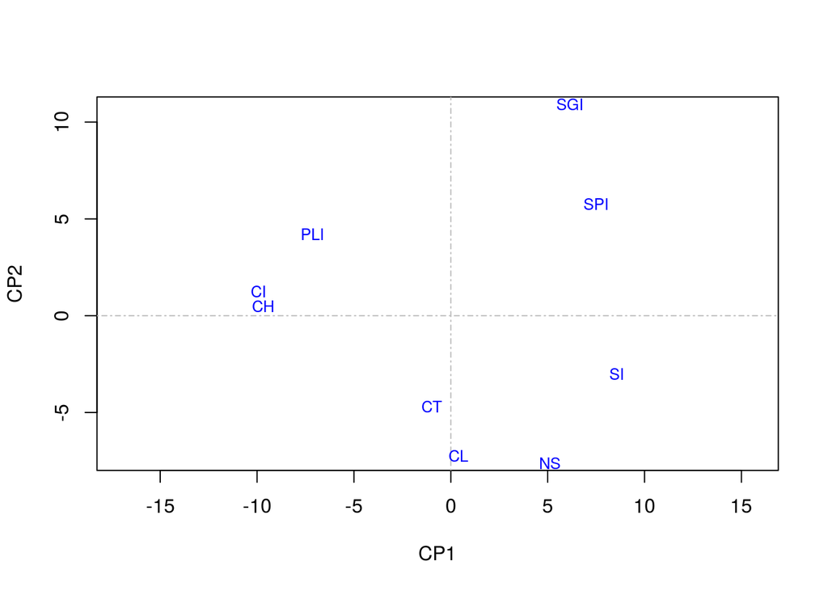

Representación gráfica de las distancias de Canberra entre las columas (lugares geográficos) de la base de datos seabirds.

```r
# draw the graph
eqscplot(MDS_CanR_columns$points[, 1:2],ty="n",xlab="CP1",ylab="CP2")
abline(v=0,h=0, col="gray",lty=4)
# draw the columns
text(MDS_CanR_columns$points[,1],MDS_CanR_columns$points[,2],labels=colnames(table_N),cex=0.8,
     col = "blue")
```

En general tiene poco que ver con la gráfica que obtuvimos de las distancias ji-cuadrado, aunque algunas características sí se mantienen. Por ejemplo, PLI-CI-CH siguen representados cerca unos de otros; así como CT-CL-NS, y SGI-SPI.

### Comparar el resultado con el obtenido con la distancia ji-cuadrado. Utilizar la función procrustes() del paquete vegan.

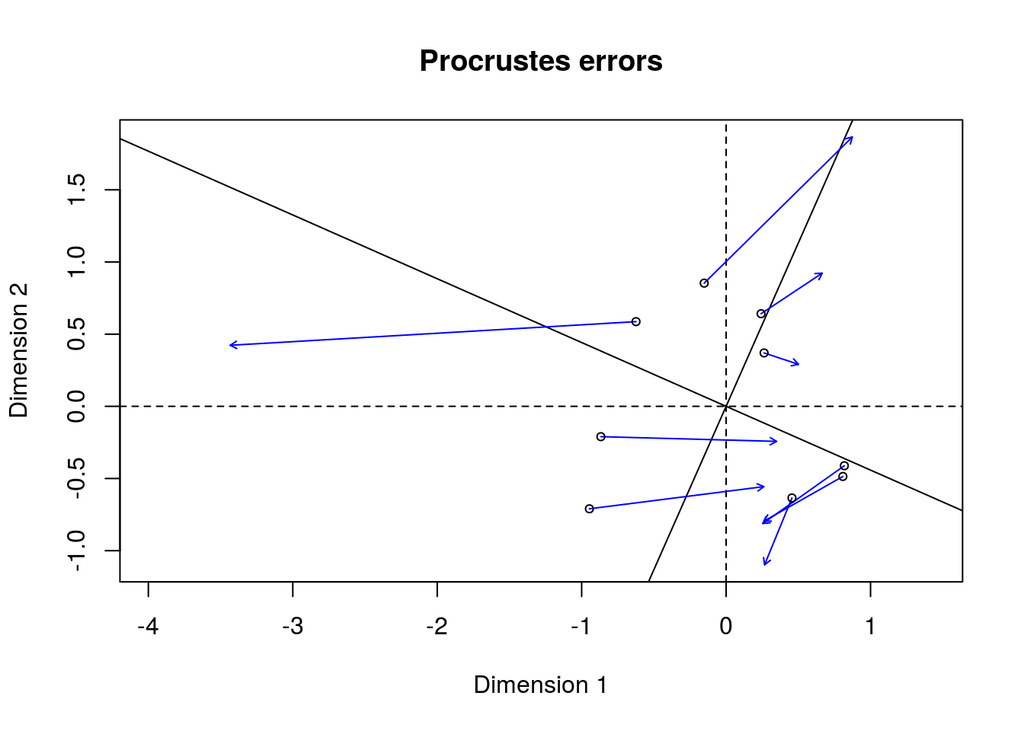

Representación de la rotación de matrices necesaria para asemejar los resultados de la matriz de distancias de Canberra a los de la matriz de distancias ji-cuadrado.

```r
proc <- procrustes(MDS_seabirds_columns$points[, 1:2], # target matrix
                   MDS_CanR_columns$points[, 1:2] # matrix to be rotated
                   )

plot(proc)
```

## 1g. Realizar un análisis de conglomerados jerárquico con el método de Ward 2 de la distancia de Canberra según R. Dibujar el dendograma resultante.

Para el análisis de conglomerados jerárquico usaremos la matriz de distancias de Canberra calculada por la función `dist()`. Sobre ella usaremos la función `hclust()` configurada para usar el método `ward.D2`, que implementa el criterio de aglomeración de Ward.

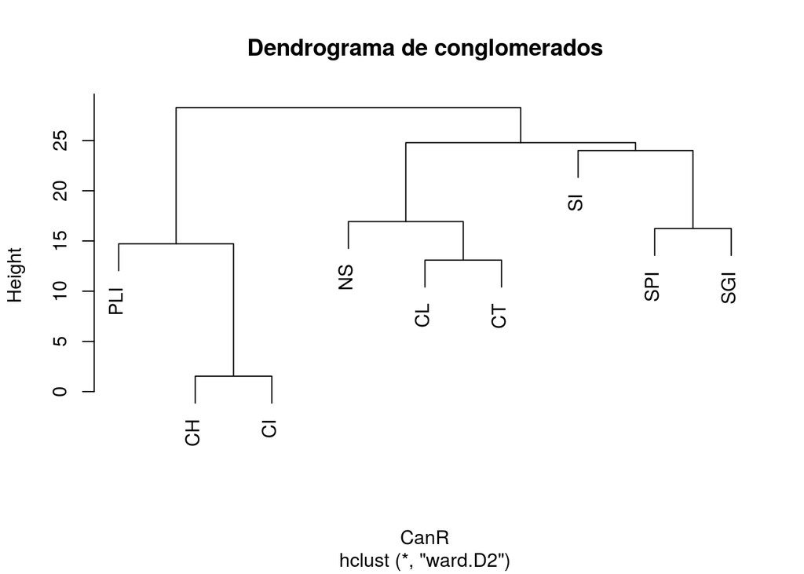

Dendrograma de conglomerados de las colonias de aves de la base de datos `seabirds` calculado a partir de distancias de Canberra. Si lo comparamos con la gráfica de coordenadas principales del apartado 1f veremos que las colonias que en aquella gráfica aparecían más cercanas entre sí, en el dendrograma están agrupadas en las mismas ramas.

```r
# Compute hierarchical clustering
Ward_clust <- hclust(CanR, method = "ward.D2")

# Plot the dendrogram
plot(Ward_clust, main = "Dendrograma de conglomerados")
```

### Dibujar también un heatmap de este análisis con la función heatmap(). Para ello, hay que elegir bien los parámetros distfun= y hclustfun= y una escala de colores. ¿Para qué sirve el heatmap?

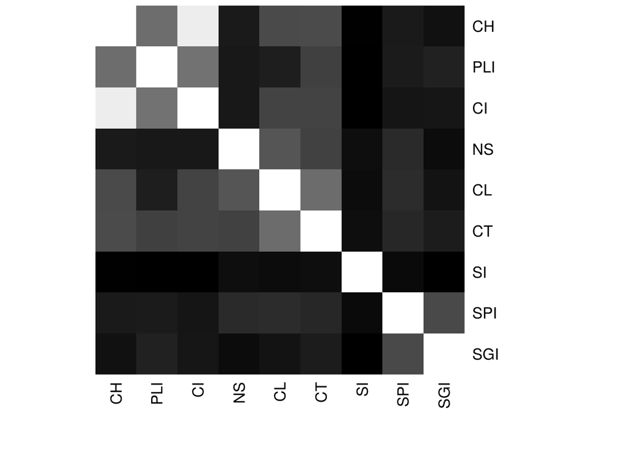

Mapa de calor de la matriz de distancias de Canberra entre las colonias de aves. La distancia está codificada como una escala de grises desde el blanco (distancia 0) hasta el negro (distancia máxima).

```r
# Color scale
greyscale <- colorRampPalette(c("white", "black"))(255)

heatmap(as.matrix(CanR),
        col = greyscale,
        Rowv = NA,
        Colv = "Rowv",
        distfun = NA,
        scale = "none")
```

## 1h. El siguiente paso es estudiar por algún criterio el número óptimo de conglomerados para el análisis jerárquico. Con la distancia de Canberra según R en particular, lo más sencillo es utilizar el criterio de las siluetas.

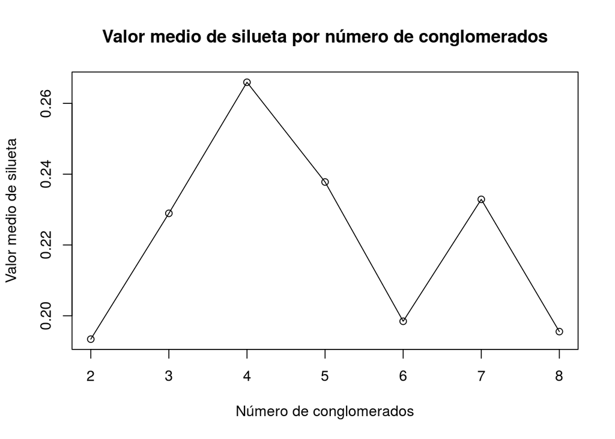

```r
# Initialize vector for storing average silhouettes
mean_sil <- c(rep(0, 7))
# Compute silhouette averages
for (i in 2:8){
  sil <- silhouette(cutree(Ward_clust, k = i), dist = CanR)
  mean_sil[i-1] <- mean(sil[, "sil_width"])
}
# Plot the averages
plot(2:8,mean_sil,type="o",xlab="Número de conglomerados", ylab = "Valor medio de silueta")
title(main="Valor medio de silueta por número de conglomerados")
```

## 1i. Estudiar con la misma distancia el número óptimo de conglomerados con el método PAM.

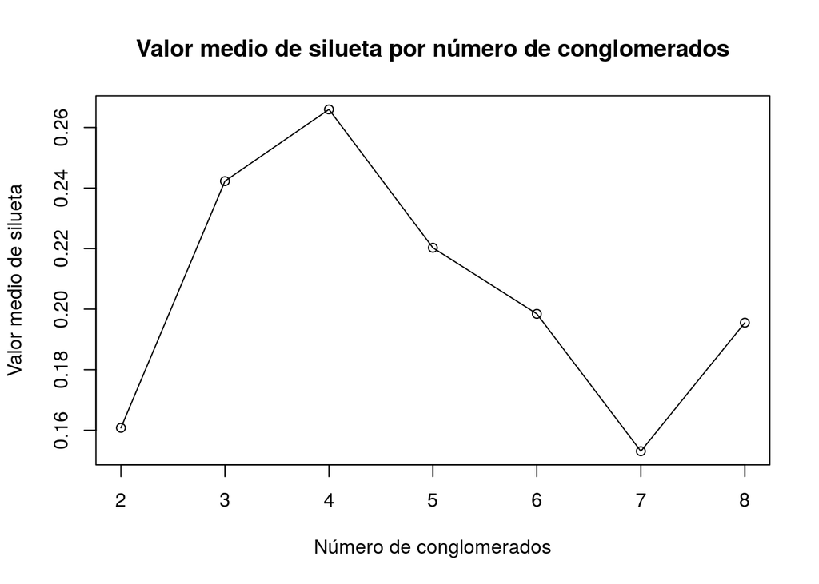

```r
# Initialize vector for storing average silhouettes
mean_sil <- c(rep(0, 7))
# Compute silhouette averages
for (i in 2:8){
  sil <- silhouette(pam(CanR, k=i))
  mean_sil[i-1] <- mean(sil[, "sil_width"])
}
# Plot the averages
plot(2:8,mean_sil,type="o",xlab="Número de conglomerados", ylab = "Valor medio de silueta")
title(main="Valor medio de silueta por número de conglomerados")
```

Si representamos los conglomerados gráficamente (sobre un plano formado por las dos primeras componentes principales):

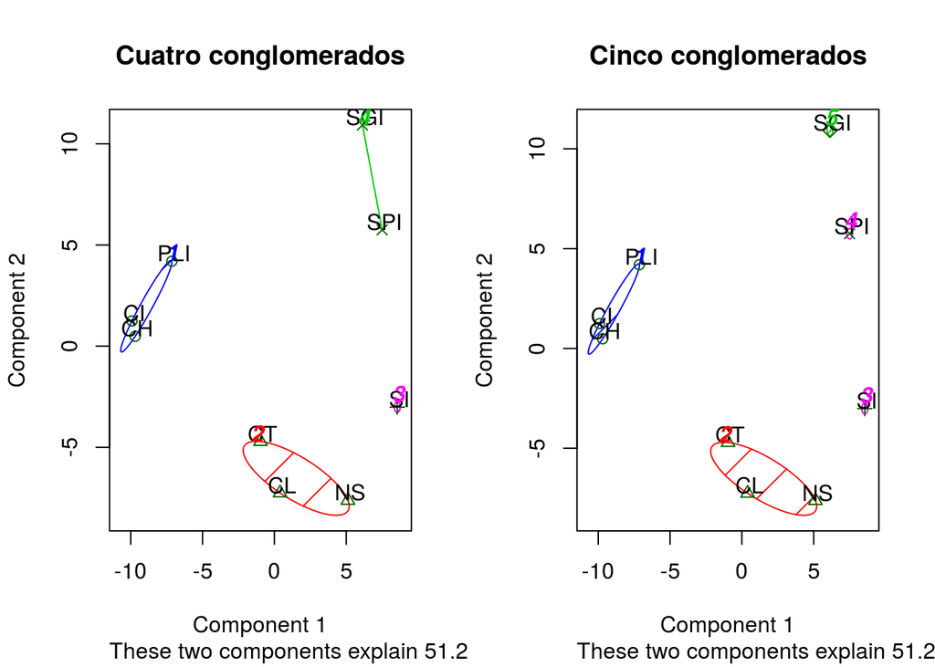

```r
par(mfrow = c(1,2))
# Four clusters
clusplot(pam(CanR, 4, diss = TRUE), color = TRUE, shade = TRUE, labels=2, lines=0, main = "Cuatro conglomerados", col.txt = "black")
# Five clusters
clusplot(pam(CanR, 5, diss = TRUE), color = TRUE, shade = TRUE, labels=2, lines=0, main = "Cinco conglomerados", col.txt = "black")
```

Intuitivamente, la división en 4 conglomerados parece tener más sentido que la división en 5.

## 1j. De los apartados anteriores se deduce que hay un número razonable de conglomerados, aunque no sea óptimo. Dibujar el dendograma del apartado (g) con esa partición.

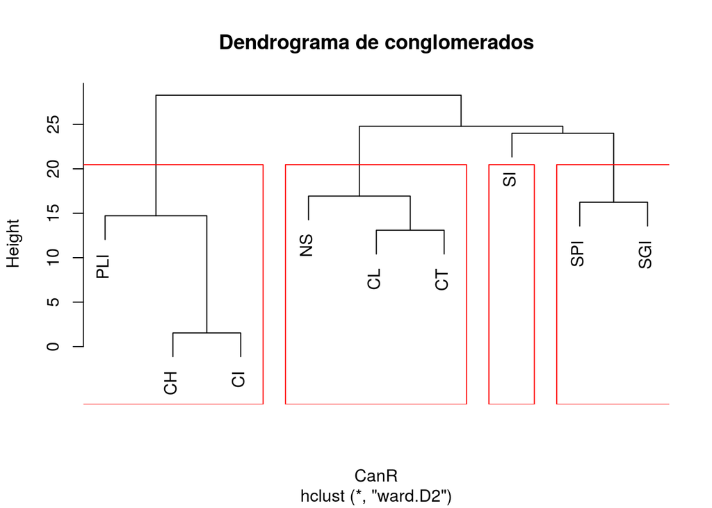

Dendrograma de conglomerados a partir de la distancia de Canberra entre colonias de aves de la base de datos `seabird`, jerarquía estructurada según el método Ward.D2. Los rectángulos rojos señalan los conglomerados en los que decidimos dividir el conjunto según los resultados del ejercicios 1h y 1i.

```r
# Plot the dendrogram
plot(Ward_clust, main = "Dendrograma de conglomerados")
rect.hclust(Ward_clust, k = 4)
```

# Ejercicio 2. Los salmones de Johnson

**Un estudio contiene dos medidas de los anillos de crecimiento en la escala del salmón de Alaska y de Canadá. Los datos se pueden obtener 3 en el libro de Johnson et al. (2002) y se adjuntan en el archivo `salmon.txt`.**

En primer lugar, como preparación al ejercicio cargaremos los datos a memoria y examinaremos las características y estructura de los mismos.

```r
salmon <- read.table("./data/salmon.txt",
                     header = TRUE)

kable(
  head(salmon),
  caption = "Ejemplo de las primeras seis observaciones en la base de datos `salmon.txt`."
)
```

Ejemplo de las primeras seis observaciones en la base de datos `salmon.txt`.

| Gender | Freshwater | Marine | Origin |
| --- | --- | --- | --- |
| 2 | 108 | 368 | Alaskan |
| 1 | 131 | 355 | Alaskan |
| 1 | 105 | 469 | Alaskan |
| 2 | 86 | 506 | Alaskan |
| 1 | 99 | 402 | Alaskan |
| 2 | 87 | 423 | Alaskan |

Si examinamos la estructura de la base de datos:

```r
str(salmon)
```

```
## 'data.frame':    100 obs. of  4 variables:
##  $ Gender    : int  2 1 1 2 1 2 1 2 2 1 ...
##  $ Freshwater: int  108 131 105 86 99 87 94 117 79 99 ...
##  $ Marine    : int  368 355 469 506 402 423 440 489 432 403 ...
##  $ Origin    : Factor w/ 2 levels "Alaskan","Canadian": 1 1 1 1 1 1 1 1 1 1 ...
```

La variable `Gender` la codificaremos como factor, no como numérica:

```r
salmon$Gender <- factor(salmon$Gender, labels = c("female", "male"))
```

**Gender:** hembra = 1 y macho = 2.  
**Freshwater**: Diámetro de los anillos del primer año de crecimiento en agua dulce (centésimas de pulgada).  
**Marine:** Diámetro de los anillos del primer año de crecimiento en ambiente marino (centésimas de pulgada).  
**Origin:** Origen del pez. 1 = Alaskan, 2 = Canadian.

Finalmente, una forma rápida de buscar valores anómalos y valores ausentes es mediante el resumen numérico:

```r
summary(salmon)
```

```
##     Gender     Freshwater        Marine           Origin
##  female:52   Min.   : 53.0   Min.   :301.0   Alaskan :50
##  male  :48   1st Qu.: 99.0   1st Qu.:367.0   Canadian:50
##              Median :117.5   Median :396.5
##              Mean   :117.9   Mean   :398.1
##              3rd Qu.:140.0   3rd Qu.:428.2
##              Max.   :179.0   Max.   :511.0
```

No parece haber valores anómalos (entendidos como imposiblemente elevados, negativos, o faltantes) en ninguna de las variables. Las variables categóricas están ambas equilibradas, especialmente *Origin*.

# Apéndice A: Código

El documento original en formato .Rmd, que incluye el código completo en lenguaje R usado para generar este informe, se puede consultar y descargar en el siguiente repositorio de Github: jorgevallejo/analisis_multivariante_pajaros

# Referencias

Greenacre, Michael. 2017. “Two-Dimensional Displays.” In *Correspondence Analysis in Practice, 3rd Edition*, 72. Boca Raton, FL: CRC Press.

Hunt Jr, George L, Zoe A Eppley, and David C Schneider. 1986. “Reproductive Performance of Seabirds: The Importance of Population and Colony Size.” *The Auk* 103 (2). Oxford University Press: 306–17.

Johnson, R.A., and D. W. Wichern. 2002. *Applied Multivariate Statistical Analysis, Fifth Edition*. Prentice Hall, International Editions.

Krebs, C.J. 2014. “Ecological Methodology, 3rd Ed. (in Prep).” https://www.zoology.ubc.ca/~krebs/books.html.

[^1]: Alternativamente, podríamos reordenar la base de datos para tener sólo tres variables; especie, lugar geográfico y número de individuos. Sin embargo, para los análisis que realizaremos más adelante resulta más cómodo considerar cada lugar geogŕafico como una variable diferente.
[^2]: En realidad si las comparamos con la expresión `as.matrix(Can3) == as.matrix(CanR)` comprobaremos que varios de los valores son reconocidos como diferentes. No sé la razón con seguridad, pero probablemente se deba a diferencias de redondeo.